# Practica 2

Carlos_Claudia

2023-04-21

# Pregunta 1.1 Descargar la página web de la URL indicada, y almacenarlo en un formato de R apto para ser tratado

```
## [1] 200
```

[output not shown]

# Pregunta 1.2 Analizar el contenido de la web, buscando el título de la página (que en HTML se etiqueta como “title”)

```
## [1] "MediaWiki"
```

# 1.3 Analizar el contenido de la web, buscando todos los enlaces (que en HTML se etiquetan como “a”), buscando el texto del enlace, así como la URL

```
## [1] "Jump to content" "Main page"       "Get MediaWiki"   "Get extensions"
## [5] "Tech blog"       "Contribute"
```

```
## [1] "#bodyContent"
## [2] "/wiki/MediaWiki"
## [3] "/wiki/Download"
## [4] "/wiki/Special:MyLanguage/Category:Extensions"
## [5] "//techblog.wikimedia.org/"
## [6] "/wiki/Special:MyLanguage/How_to_contribute"
```

# 1.4 Generar una tabla con cada enlace encontrado, indicando el texto que acompaña el enlace, y el número de veces que aparece un enlace con ese mismo objetivo.

```
##                                        Link        Text Count
## 29                          /wiki/MediaWiki   Main page     5
## 30                          /wiki/MediaWiki                 5
## 31                          /wiki/MediaWiki   Main Page     5
## 32                          /wiki/MediaWiki        Read     5
## 33                          /wiki/MediaWiki        Read     5
## 6  /w/index.php?title=MediaWiki&action=edit View source     2
```

# 1.5 Para cada enlace, seguirlo e indicar si está activo (podemos usar el código de status HTTP al hacer una petición a esa URL) aparece un enlace con ese mismo objetivo

```
## [1] 200 200 200 200 404 200
```

#Pregunta 2.1 Un histograma con la frecuencia de aparición de los enlaces, pero separado por URLs absolutas (con “http…”) y URLs relativas.

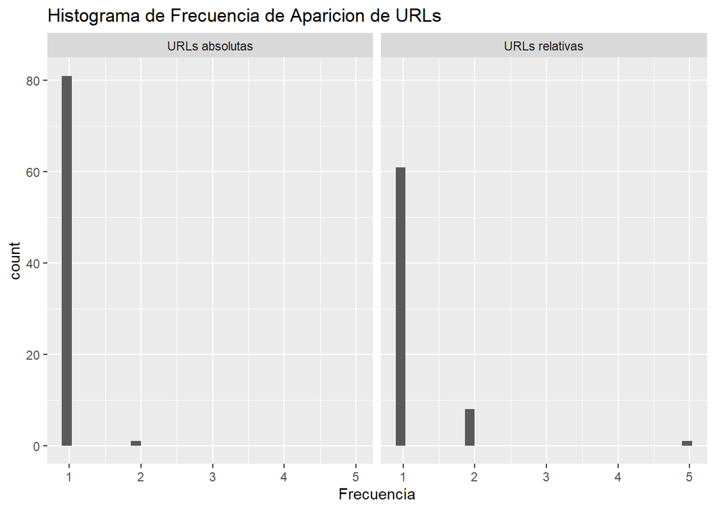

[output not shown]

#Pregunta 2.2 Un gráfico de barras indicando la suma de enlaces que apuntan a otros dominios o servicios vs. la suma de los otros enlaces.

[figure not shown]

#Pregunta 2.3 Un gráfico de tarta (pie chart) indicando los porcentajes de Status de nuestro análisis.

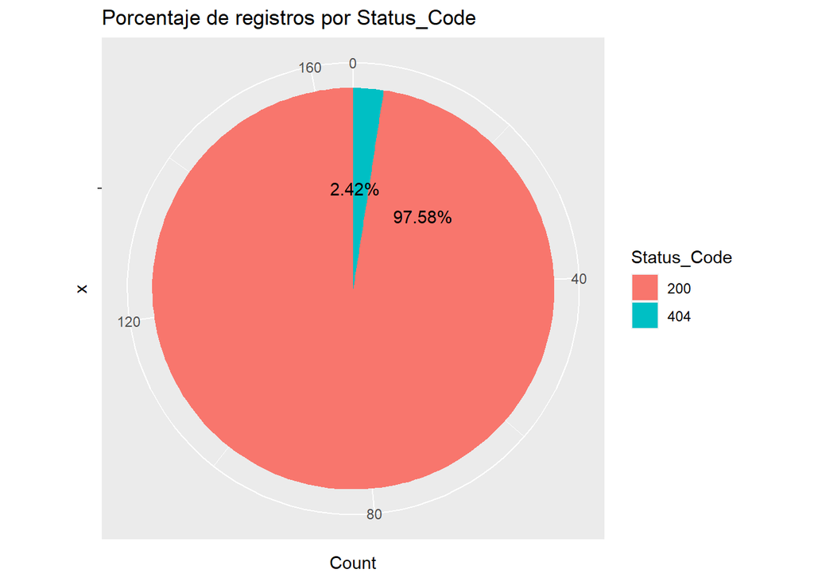